# AtlasVPM: Atlas de Farmacia

Variaciones en el consumo **Opioides** por Zona Básica de Salud

Autor/a

Afiliaciones

[Atlas de Variaciones injustificadas de la Práctica Médica (Atlas VPM)](https://cienciadedatosysalud.org/)

Grupo de Ciencia de datos para la investigación en servicios y políticas sanitarias

Instituto Aragonés de Ciencias de la Salud (IACS)

Red de Investigación en Cronicidad, Atención Primaria y Prevención y Promoción de la Salud (RICAPPS)

Fecha de publicación

24 de noviembre de 2026

Versión de los análisis: 0.0.5

# Resumen ejecutivo

Con variación en la evolución anual y entre CCAA, en torno al 64% de los envases dispensados correspondieron a opioides en combinación con analgésicos, el 16% a otros opioides, el 11% a derivados de la fenilpiperidina, el 7% a alcaloides naturales del opio y el 2% a derivados de oripavina.

Para el conjunto de opioides analizados y años, la variación de DHD entre las ZBS de más y menos consumo, sin considerar las ZBS con valores extremos fue elevada, en torno a una razón de variación de 3 veces las DHD entre estas ZBS. Por subgrupos terapéuticos, esta variación fue todavía mayor, siendo la más elevada la de opioides en combinación con analgésicos con una razón de variación de 11,8 entre las ZBS de más y menos consumo, seguida de derivados de oripavina con una razón de 8,7, alcaloides naturales del opio con una razón de 5,7, derivados de la fenilpiperidina con una razón de 4,8 y finalmente otros opioides con una razón de 3,5.

# Contexto

Este informe pertenece a la serie de informes de AtlasVPM sobre Farmacia, en el que se incluyen el análisis de consumo de Opioides y de Antibióticos. En este informe nos referimos a consumo como la dispensación ambulatoria de un fármaco en oficina de farmacia a una persona con tarjeta sanitaria en el Sistema Nacional de Salud (SNS). El consumo de los medicamentos está mediado por la prescripción de un profesional sanitario -principalmente los médicos especialistas en medicina familiar y comunitaria- y, en el caso de algunos medicamentos, al visado de la receta médica por un inspector del SNS. La utilización de los medicamentos, como sucede con otras tecnologías sanitarias, está sujeta a una gran variabilidad. El análisis de las *variaciones en la práctica médica*, entendidas como las variaciones sistemáticas -no aleatorias- en las tasas estandarizadas de una exposición o intervención sanitaria (i.e., consumo de medicamento) al nivel que se produce la toma de decisiones sobre esta exposición o intervención sanitaria, en este caso, a nivel de Zona Básica de Salud (ZBS), es indispensable para identificar potenciales problemas de gestión sanitaria y ayudar a orientar la toma de decisiones sobre los servicios de salud. Las variaciones sistemáticas en los patrones de dispensación de medicamentos antibióticos y opioides suponen un desafío importante para todos los Sistemas de Salud.

**Atención**

Debe tenerse en cuenta que, cuando se habla de grupos mayores (N02AA, N02AB, N02AX, N02AJ, N02AE) o total (N02A) de Opioides en este estudio, estos ATC no incluyen todos los opioides sino sólo aquellos seleccionados como relevantes para estudio que aparecen en Sección 4.3 (para más información descargar el fichero ([Modelo de datos](https://github.com/cienciadedatosysalud/atlas-farmacia/blob/main/atlas_opioides/docs/CDM/common_datamodel.xlsx))

# Resultados

En este estudio participan un total de 10 comunidades autónomas, con una población global mayor de 14 años de 17,287,586 en el año 2024, de la cual, la media mensual de personas distintas que han sido dispensadas de algún opioide (ATC = N02A) durante el periodo de estudio 2017 a 2024 es de un 3.63%.

**Descripción tabla**

La siguiente tabla muestra el número de envases totales por año, la aportación al mismo por cada comunidad autónoma, sexo y para el conjunto específico de categorías TSI (0,1,2, y 4).

Tabla descriptiva anual: Nº envases (%)

Opioides (N02A)

|  | 2017 | 2018 | 2019 | 2020 | 2021 | 2022 | 2023 | 2024 |
| --- | --- | --- | --- | --- | --- | --- | --- | --- |
| Total Nº envases anual |  |  |  |  |  |  |  |  |
| Nº envases | 8602994 | 9893174 | 10302875 | 10513336 | 10968262 | 11951029 | 12105914 | 12340275 |
| CCAA |  |  |  |  |  |  |  |  |
| Asturias | 807014 (9.38%) | 802812 (8.11%) | 824568 (8%) | 801024 (7.62%) | 827055 (7.54%) | 904615 (7.57%) | 980879 (8.1%) | 1001861 (8.12%) |
| País Vasco | 1426362 (16.58%) | 1474020 (14.9%) | 1469649 (14.26%) | 1404528 (13.36%) | 1397666 (12.74%) | 1439704 (12.05%) | 1431659 (11.83%) | 1442380 (11.69%) |
| Navarra | 149070 (1.73%) | 167428 (1.69%) | 179630 (1.74%) | 170921 (1.63%) | 184307 (1.68%) | 212550 (1.78%) | 222418 (1.84%) | 236599 (1.92%) |
| La Rioja | 182146 (2.12%) | 185500 (1.88%) | 187048 (1.82%) | 172318 (1.64%) | 171017 (1.56%) | 188318 (1.58%) | 188485 (1.56%) | 189451 (1.54%) |
| Aragón | 938683 (10.91%) | 965517 (9.76%) | 984743 (9.56%) | 964078 (9.17%) | 1078843 (9.84%) | 1041380 (8.71%) | 982781 (8.12%) | 946403 (7.67%) |
| Madrid | 2476866 (28.79%) | 2588874 (26.17%) | 2714964 (26.35%) | 2512859 (23.9%) | 2537543 (23.14%) | 2828497 (23.67%) | 2881278 (23.8%) | 2876028 (23.31%) |
| Castilla y León | 1466979 (17.05%) | 1519802 (15.36%) | 1578013 (15.32%) | 1513320 (14.39%) | 1563505 (14.25%) | 1738687 (14.55%) | 1725933 (14.26%) | 1728000 (14%) |
| Canarias | 1155874 (13.44%) | 1258309 (12.72%) | 1399269 (13.58%) | 1490766 (14.18%) | 1638219 (14.94%) | 1800559 (15.07%) | 1780838 (14.71%) | 1890822 (15.32%) |
| Región de Murcia | NA | 930912 (9.41%) | 964991 (9.37%) | 873496 (8.31%) | 925017 (8.43%) | 1103606 (9.23%) | 1185833 (9.8%) | 1347873 (10.92%) |
| Baleares | NA | NA | NA | 610026 (5.8%) | 645090 (5.88%) | 693113 (5.8%) | 725810 (6%) | 680858 (5.52%) |
| Sexo |  |  |  |  |  |  |  |  |
| Hombres | 2621331 (30.47%) | 3095456 (31.29%) | 3254460 (31.59%) | 3346247 (31.83%) | 3508156 (31.98%) | 3921551 (32.81%) | 4047069 (33.43%) | 4198061 (34.02%) |
| Mujeres | 5981663 (69.53%) | 6797718 (68.71%) | 7048415 (68.41%) | 7167089 (68.17%) | 7460106 (68.02%) | 8029478 (67.19%) | 8058845 (66.57%) | 8142214 (65.98%) |
| Conjunto categorías TSI < 18.000 € (Categorías 0, 1, 2, 4) |  |  |  |  |  |  |  |  |
| Conjunto categorías TSI < 18.000 € (Categorías 0, 1, 2, 4) | 7122233 (82.79%) | 8229390 (83.18%) | 8612185 (83.59%) | 8552136 (81.35%) | 8847948 (80.67%) | 9545562 (79.87%) | 9421331 (77.82%) | 9367130 (75.91%) |

## Porcentaje de envases dispensados por subgrupo terapéutico

**Descripción figura**

Para el total de envases dispensados (suma de todas las comunidades autónomas participantes) en toda la serie temporal, se muestra el porcentaje de envases por cada subgrupo terapéutico.

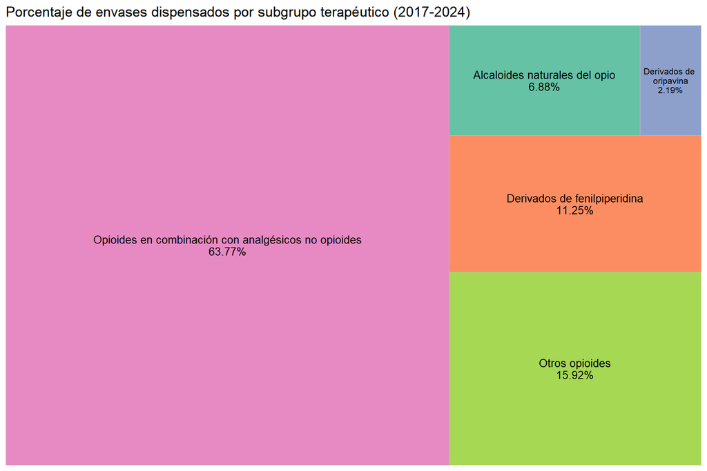

## Evolución temporal del porcentaje de envases dispensados por subgrupo terapéutico

**Descripción figura**

Para el total de envases dispensados en toda la serie temporal en cada comunidad autónoma, se muestra el porcentaje de envases por cada subgrupo terapéutico.

La leyenda es, de acuerdo con la figura anterior,:

- Alcaloides naturales del opio (N02AA),
- Derivados de fenilpiperidina (N02AB),
- Derivados de oripavina (N02AE),
- Opioides en combinación con analgésicos no opioides (N02AJ),
- Otros opioides (N02AX),

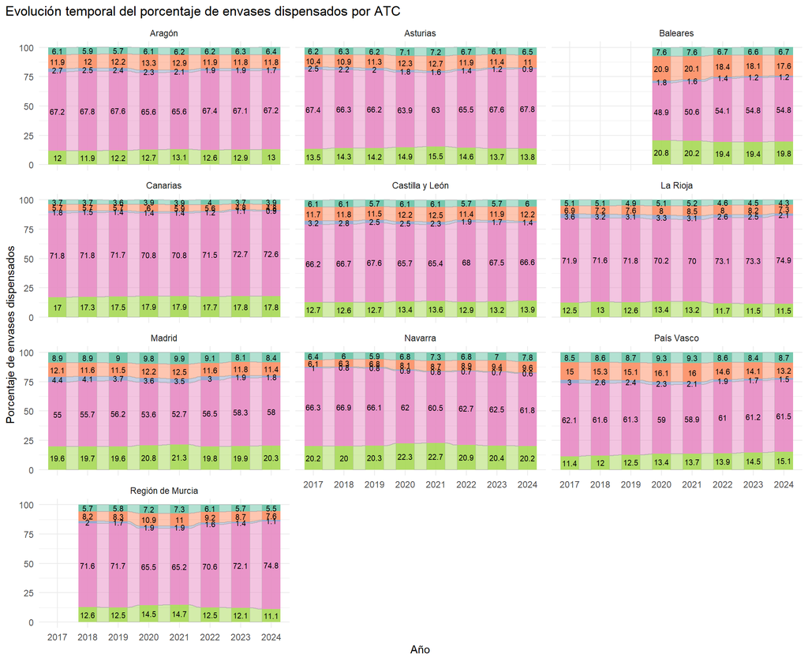

## Distribución de la población con alguna dispensación de opioides (*N02A*) por grupo de edad y sexo

**Descripción figura**

Se muestra la distribución de la población con dispensaciones por grupo quinquenal de edad y sexo en toda la serie temporal.

Para la comunidad autónoma de Baleares la serie temporal es de 2020 a 2024.

Para la comunidad autónoma de Murcia la serie temporal es de 2018 a 2024.

Para el resto de comunidades es 2017-2024.

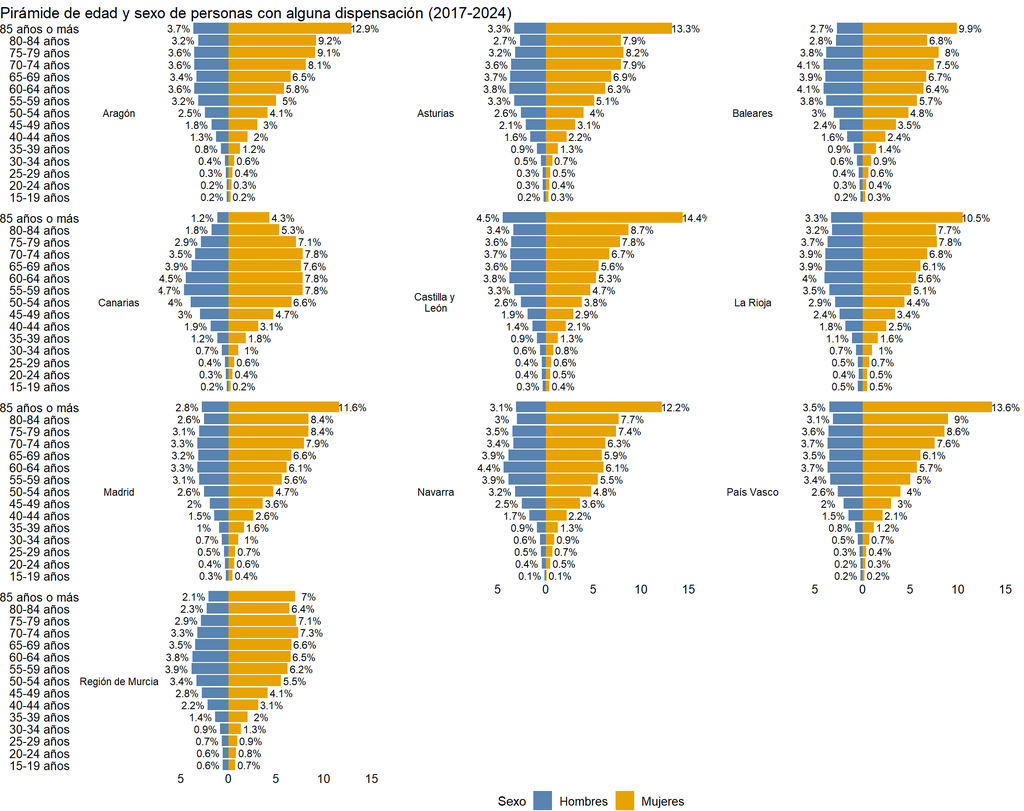

## Porcentaje de población con alguna dispensación de opioides (*N02A*) en cada mes para el conjunto de la serie temporal y por sexo

**Descripción figura**

Se muestra la distribución de la población con dispensaciones por sexo y mes en toda la serie temporal. Se construye calculando el porcentaje de personas con alguna dispensación por sexo para cada mes de cada año y luego realizando la media de cada mes a lo largo de la serie temporal.

Para la comunidad autónoma de Baleares la serie temporal es de 2020 a 2024.

Para la comunidad autónoma de Murcia la serie temporal es de 2018 a 2024.

Para el resto de comunidades es 2017-2024.

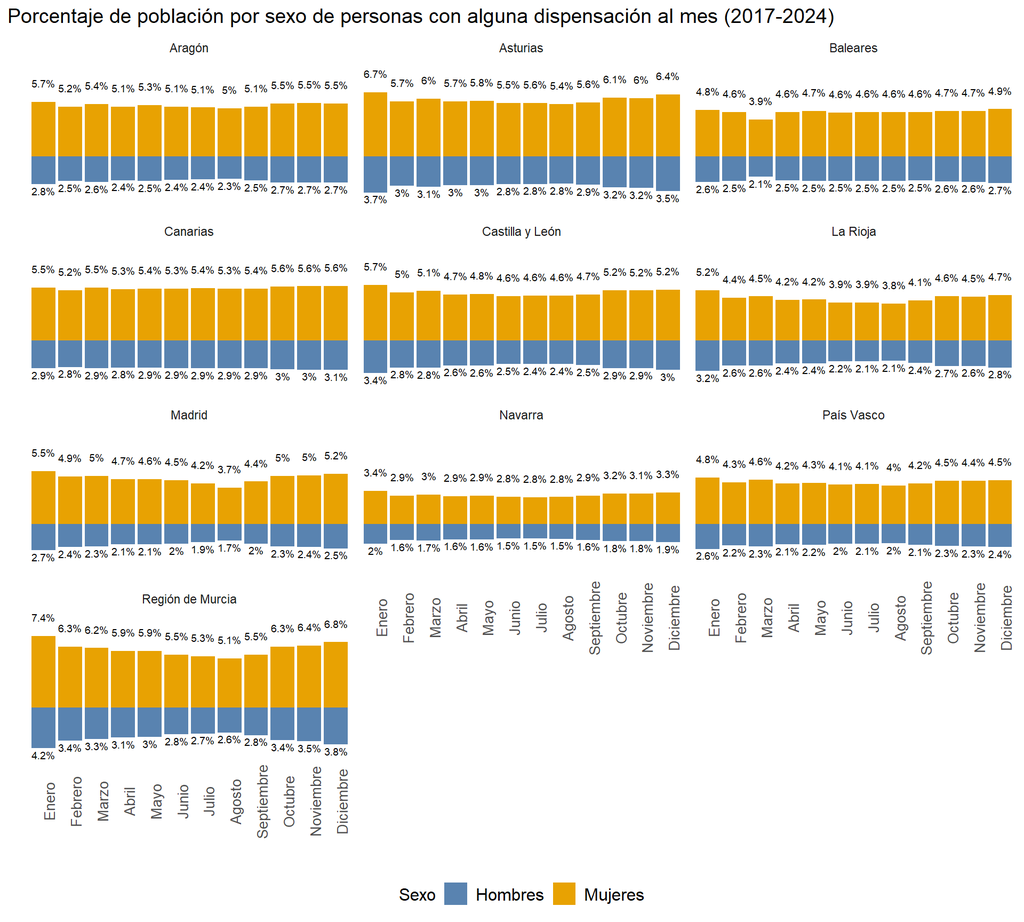

## Evolución de la variación de consumo por ZBS (SNS)

**Descripción figura**

Se muestra la variación (mediante violines) del consumo (DHD) en las zonas básicas de salud que componen el sistema nacional de salud de manera que cada punto es una zona básica. Las líneas discontinuas negras son la mediana (P50) anual y la línea discontinua roja (P50 global) es la mediana de toda la serie temporal.

**Opioides (N02A)**

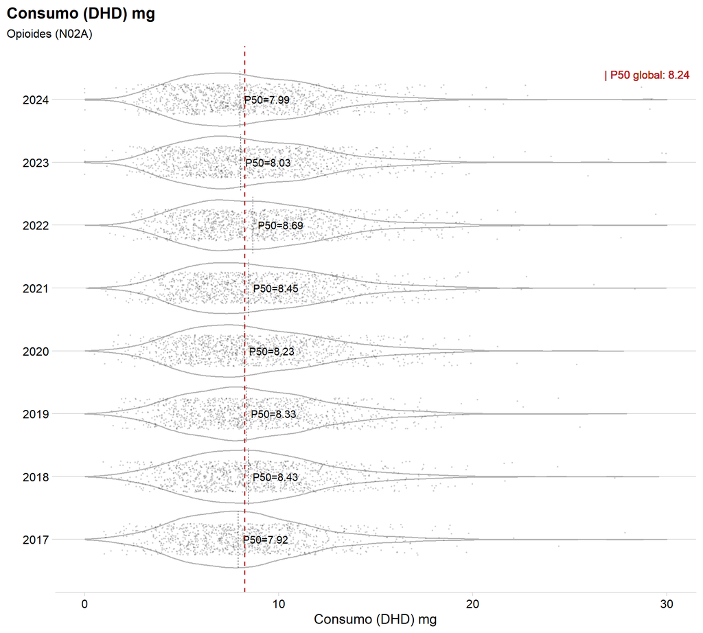

**Alcaloides naturales del opio (N02AA)**

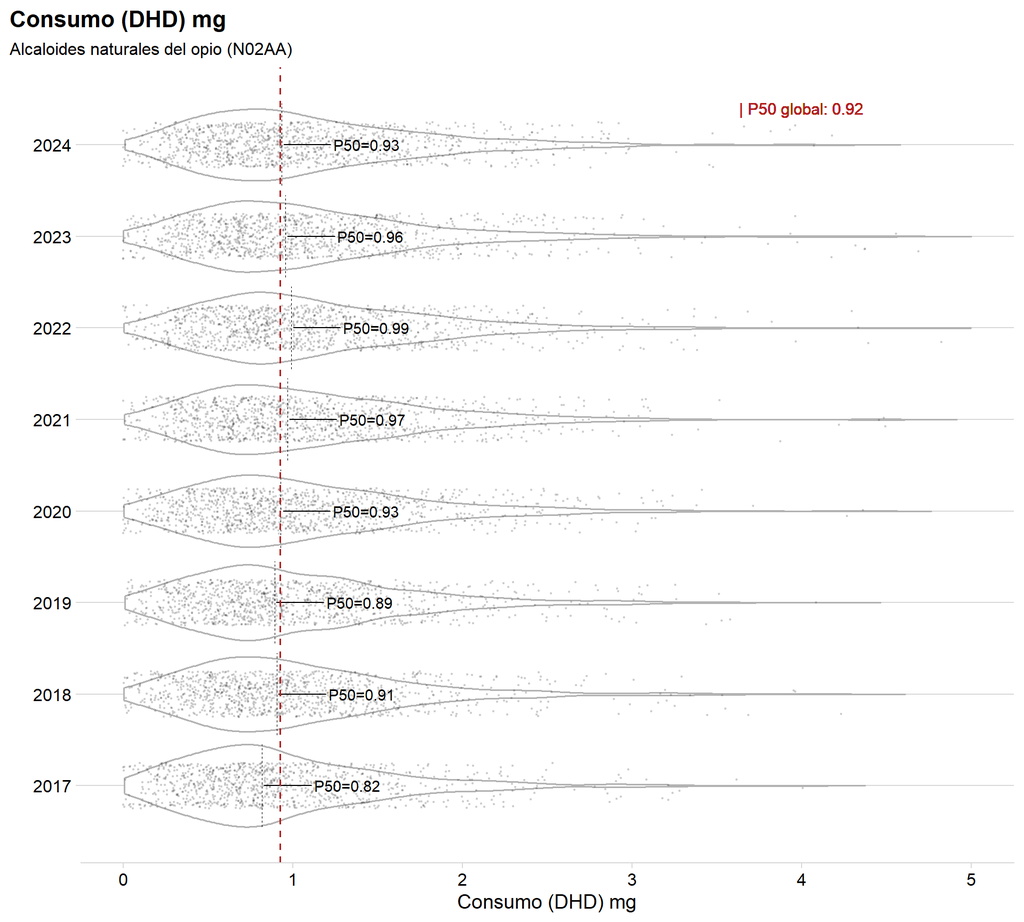

**Derivados de fenilpiperidina (N02AB)**

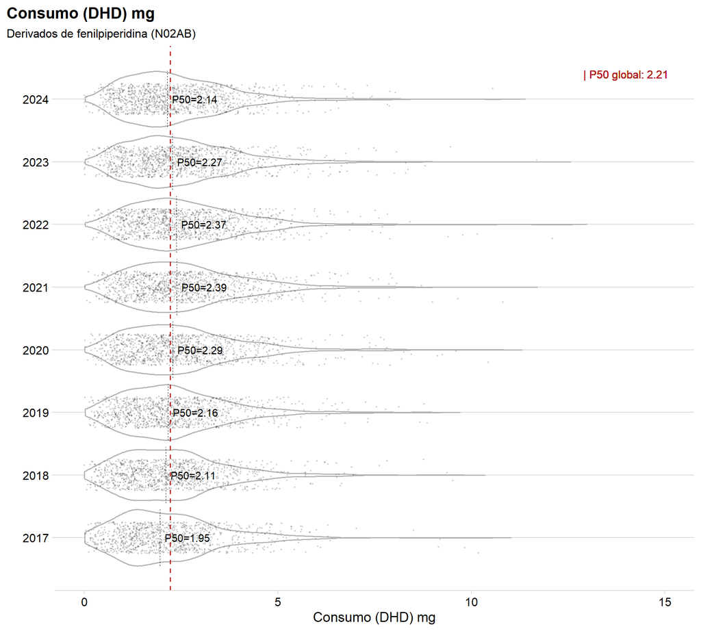

**Otros opioides (N02AX)**

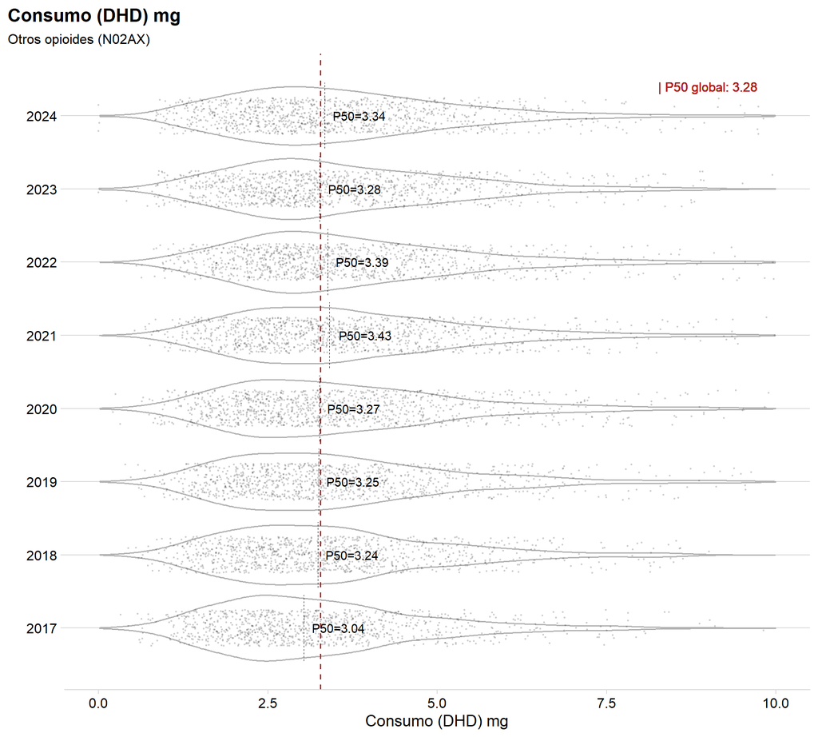

**Opioides en combinación con analgésicos no opioides (N02AJ)**

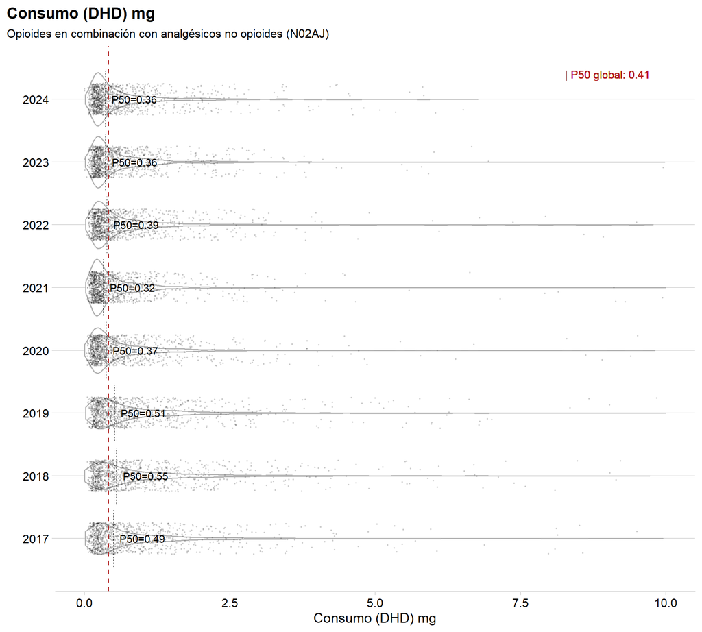

**Derivados de oripavina (N02AE)**

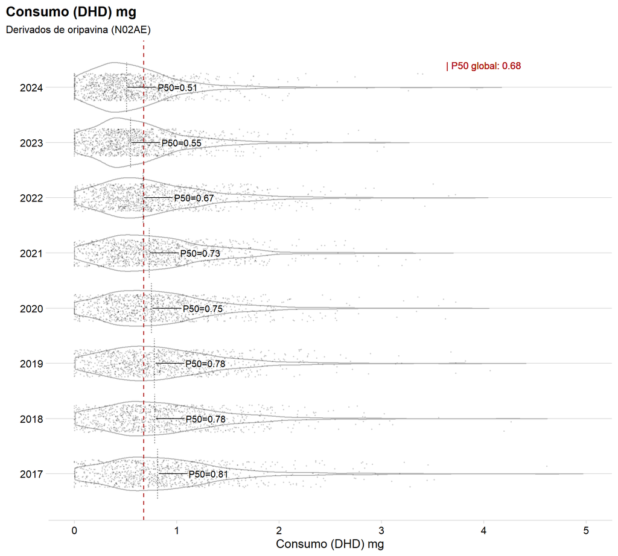

## Evolución de la variación de consumo por ZBS y TSI (SNS)

La comunidad autónoma de Baleares no presenta datos para esta gráfica.

**Descripción figura**

Se muestra la variación (mediante violines) del consumo (DHD) en las zonas básicas de salud que componen el sistema nacional de salud de manera que cada punto es una zona básica. Las líneas discontinuas negras son la mediana (P50) anual y la línea discontinua roja (P50 global) es la mediana de toda la serie temporal. Se comparan: categorías TSI < 18.000 € vs categorías TSI >= 18.000 €.

**Opioides (N02A)**

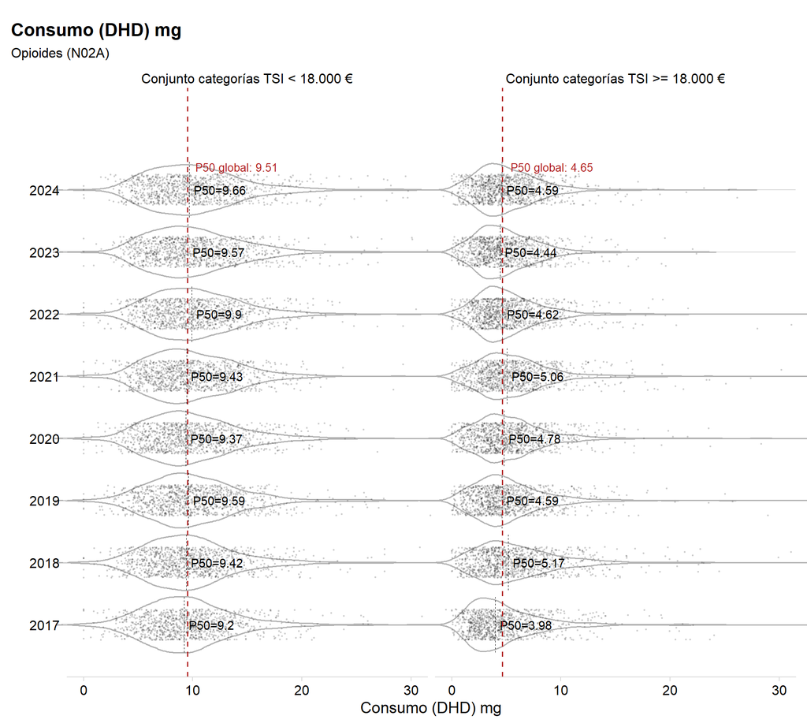

**Alcaloides naturales del opio (N02AA)**

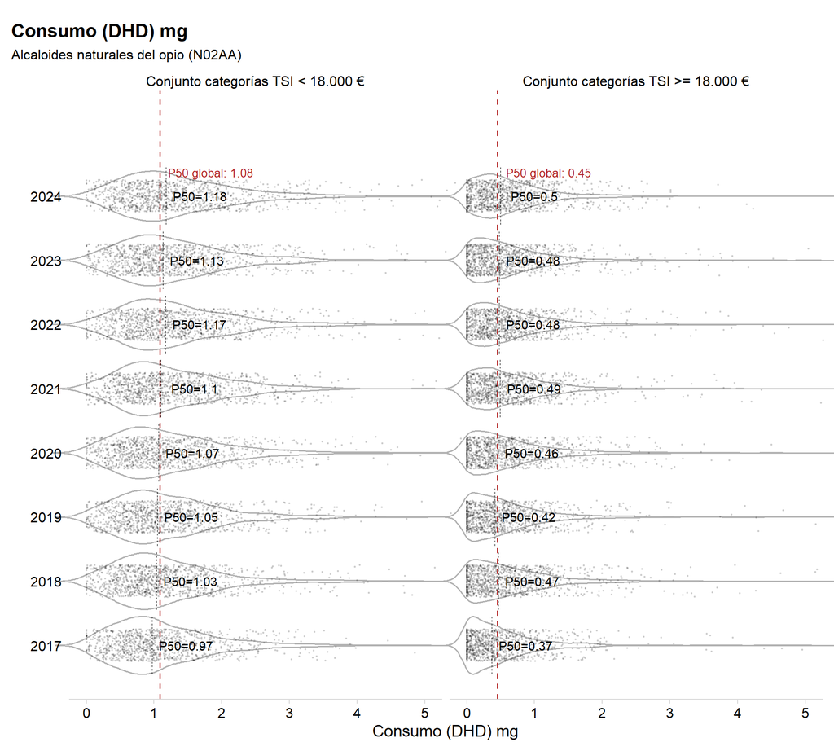

**Derivados de fenilpiperidina (N02AB)**

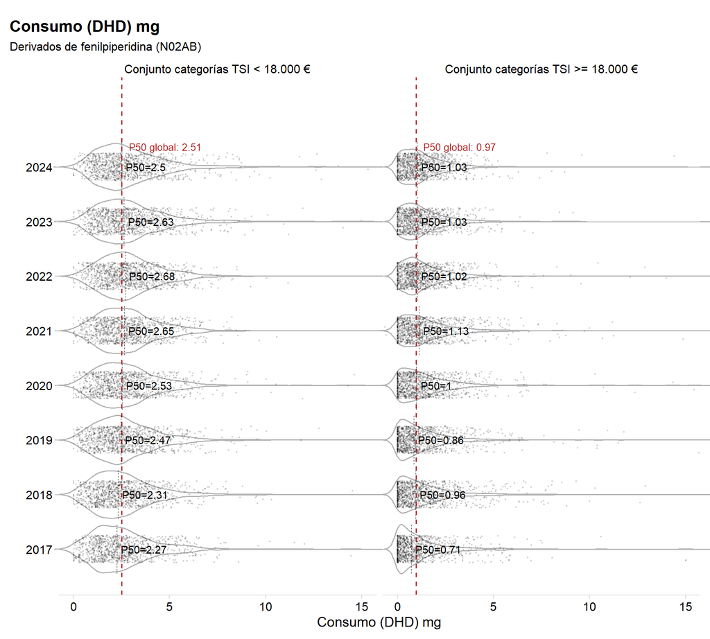

**Otros opioides (N02AX)**

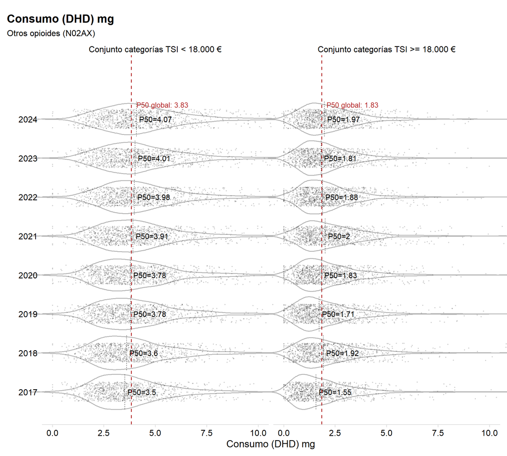

**Opioides en combinación con analgésicos no opioides (N02AJ)**

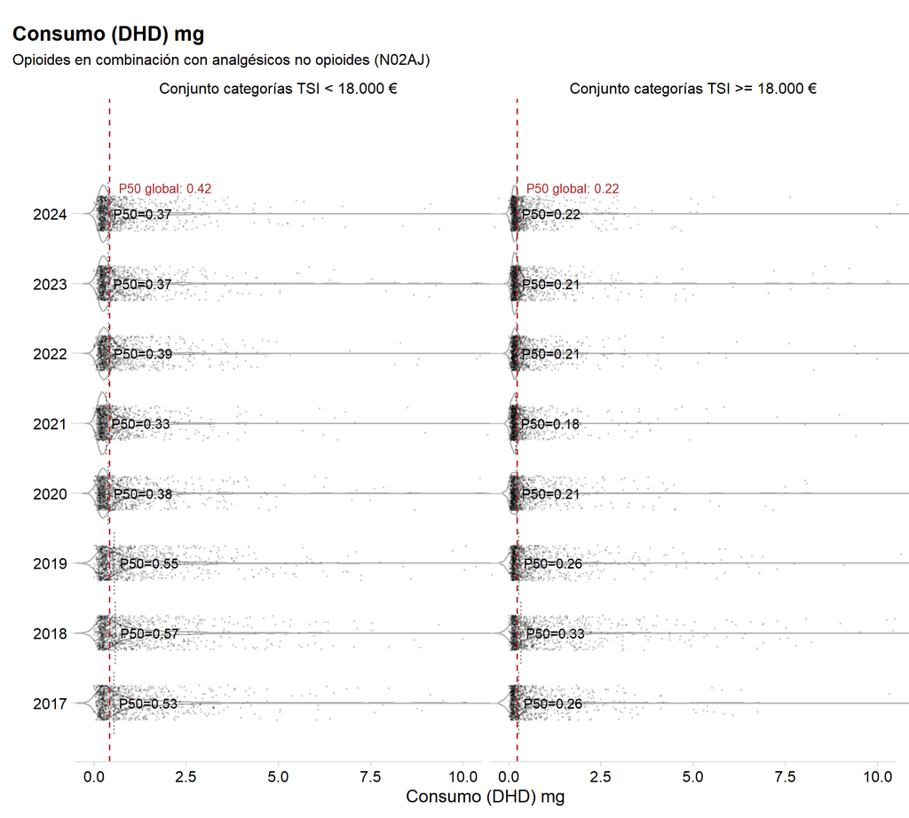

**Derivados de oripavina (N02AE)**

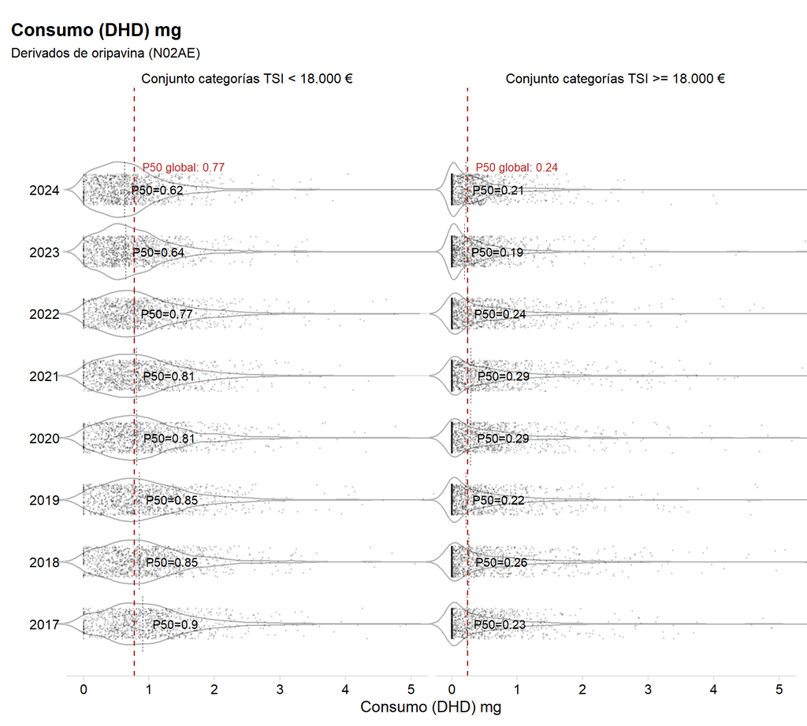

## Evolución de la variación de consumo (DHD) por ZBS y por CCAA

**Descripción figura**

Se muestra la evolución de la variación por CCAA del consumo (DHD) en las zonas básicas de salud que componen el sistema nacional de salud de manera que cada punto es una zona básica. La línea sólida roja es la mediana nacional y la zona sobreada gris es el rango intercuartílico, por lo que son comunes a todas las comunidades.

**Opioides (N02A)**

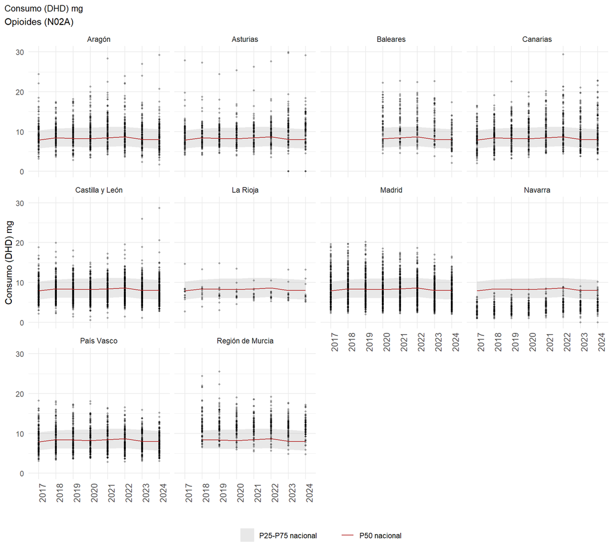

**Alcaloides naturales del opio (N02AA)**

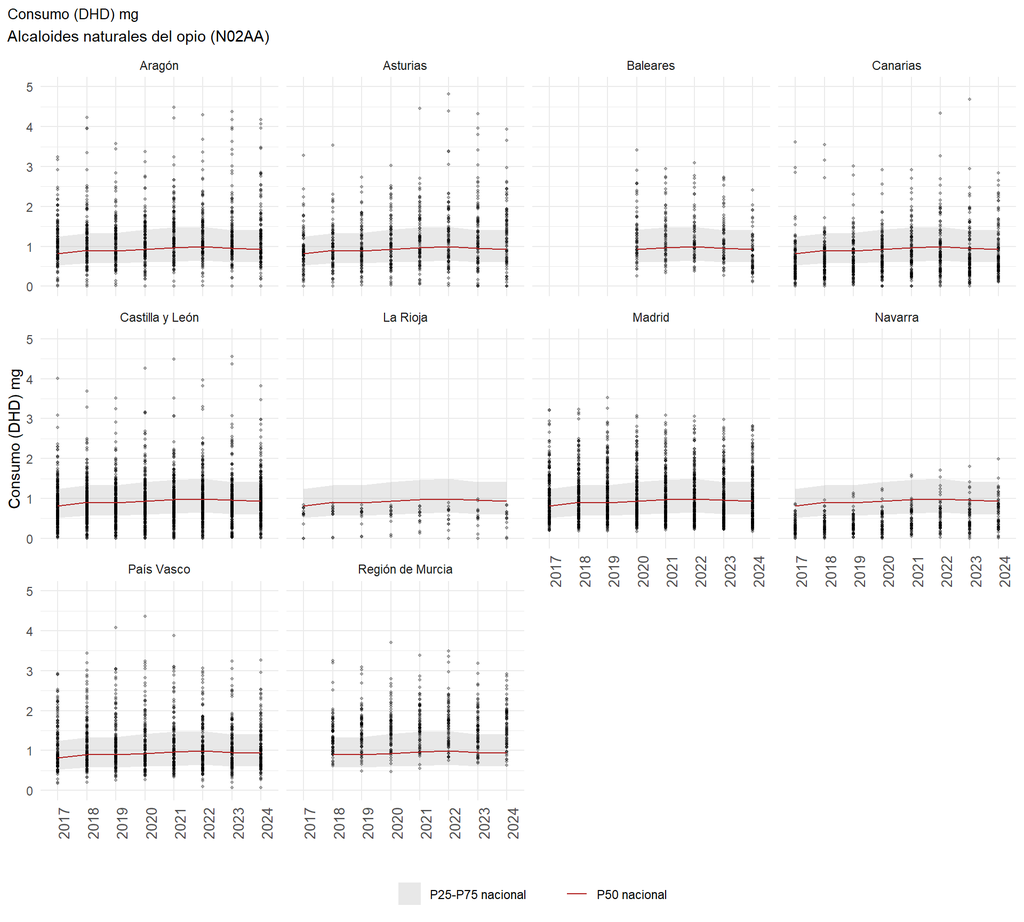

**Derivados de fenilpiperidina (N02AB)**

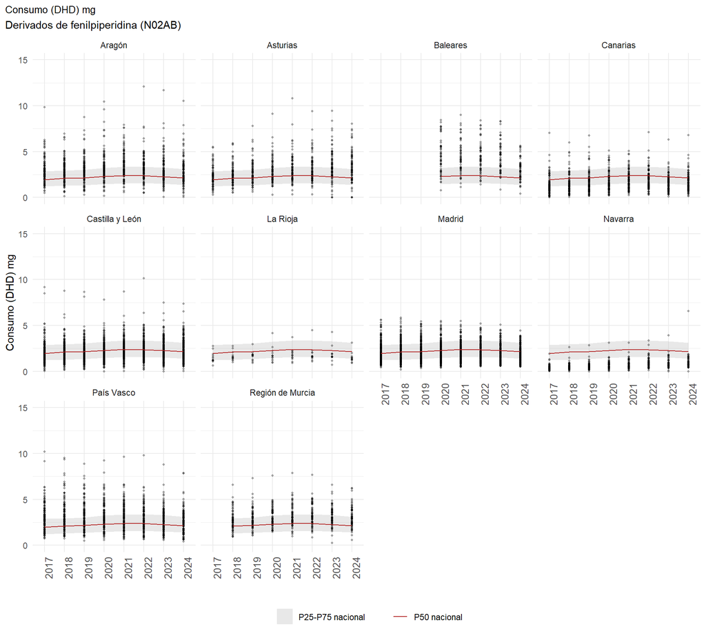

**Otros opioides (N02AX)**

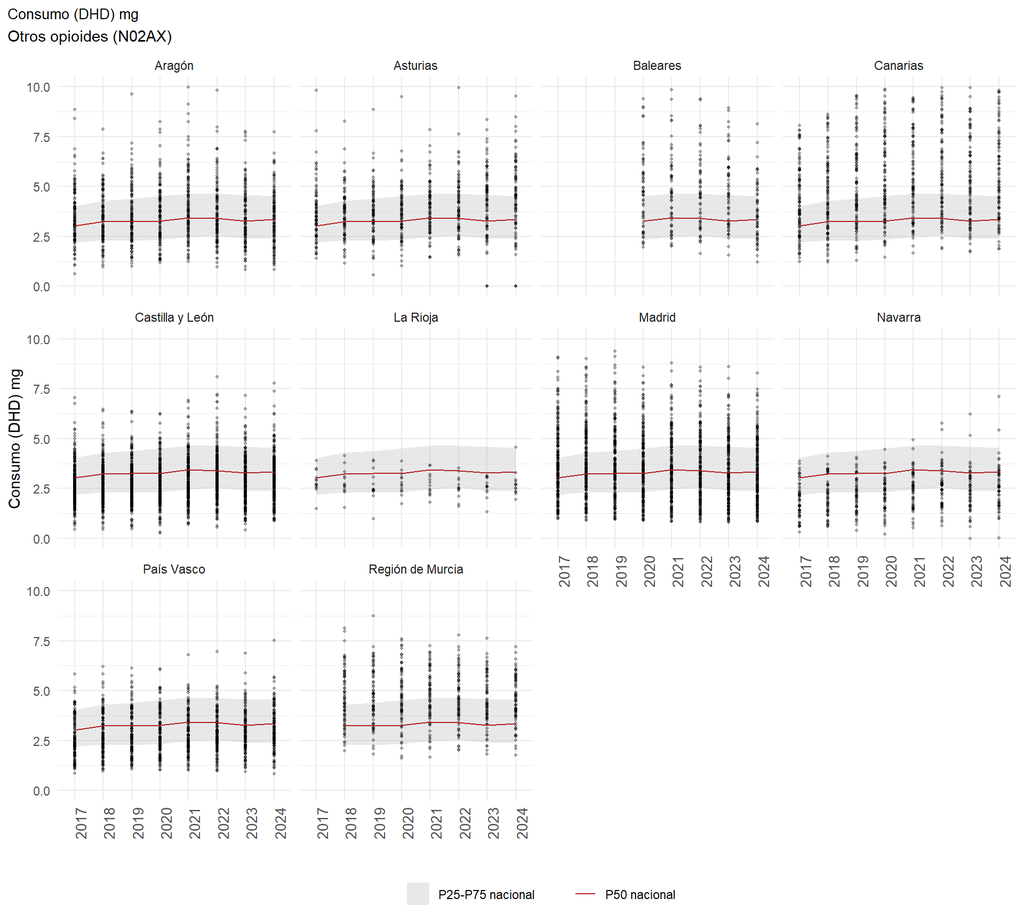

**Opioides en combinación con analgésicos no opioides (N02AJ)**

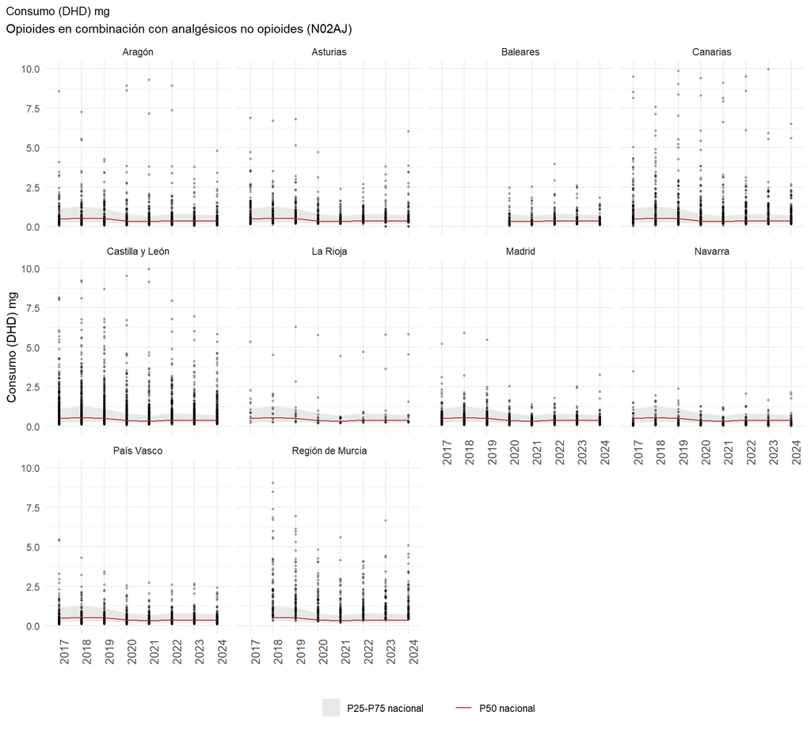

**Derivados de oripavina (N02AE)**

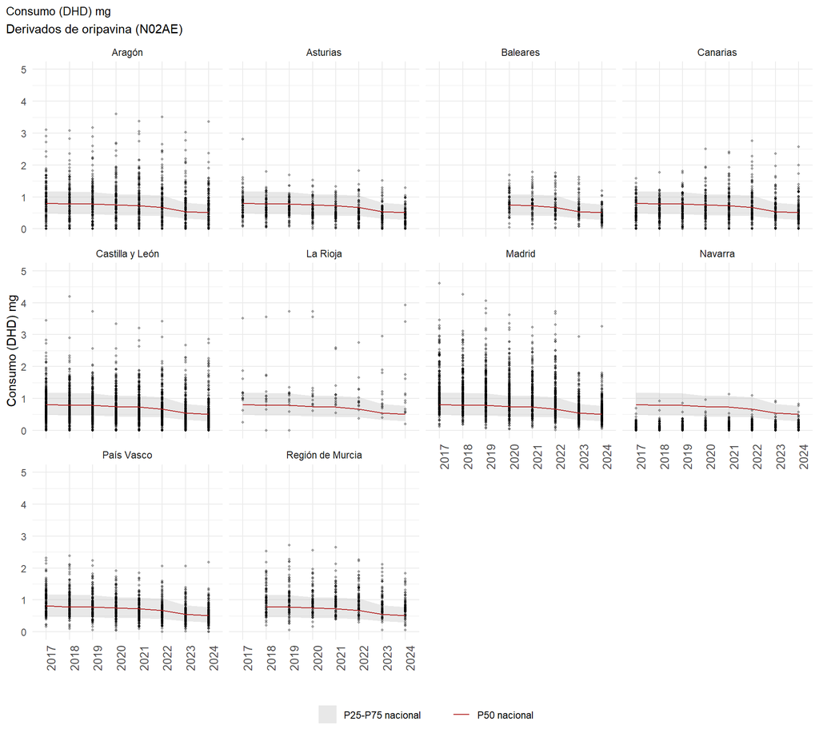

## Variación geográfica de consumo (DHD) de opioides en el año 2024

**Descripción figura**

Se muestra la variación geográfica mediante mapas por CCAA del consumo (DHD) en las zonas básicas de salud que componen el sistema nacional de salud para el último año disponible. La figura está coloreada por quintiles calculados a nivel nacional.

**Opioides (N02A)**

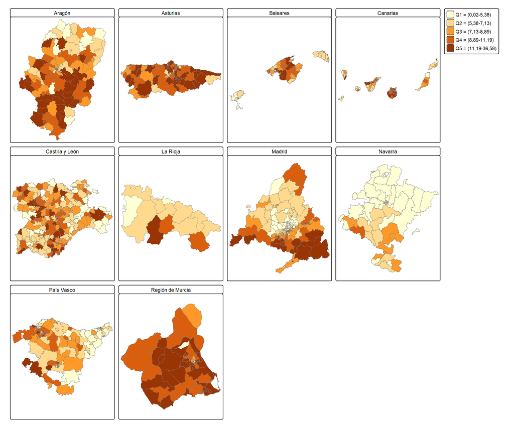

**Alcaloides naturales del opio (N02AA)**

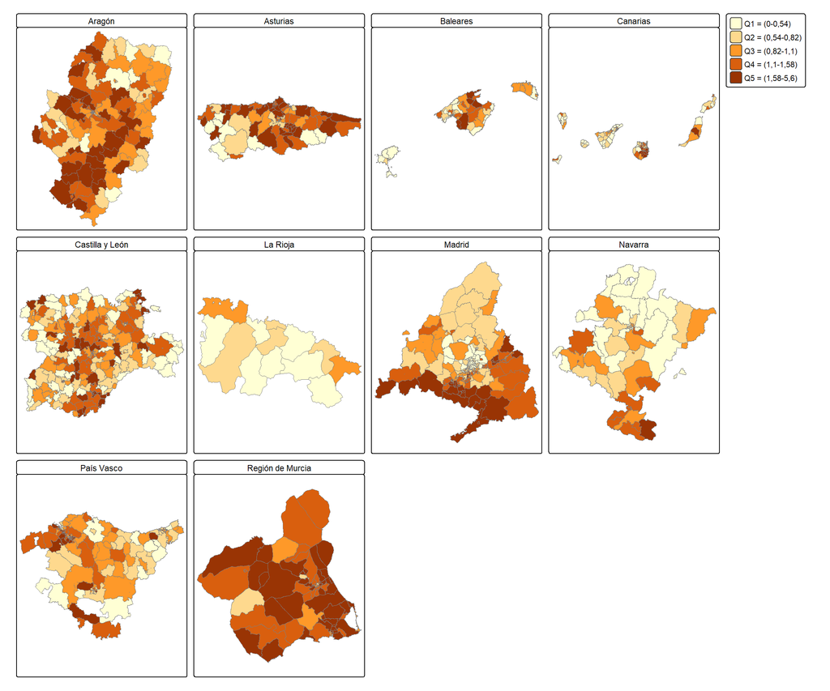

**Derivados de fenilpiperidina (N02AB)**

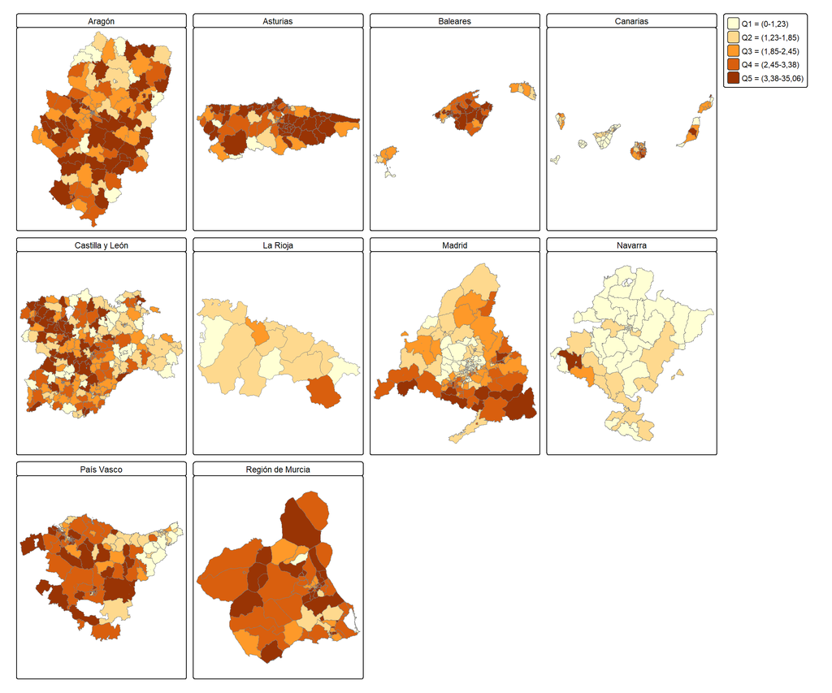

**Otros opioides (N02AX)**

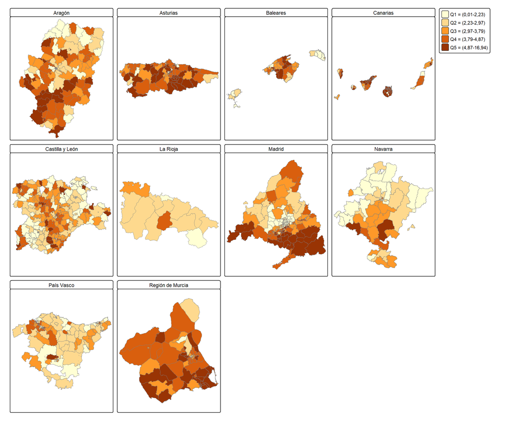

**Opioides en combinación con analgésicos no opioides (N02AJ)**

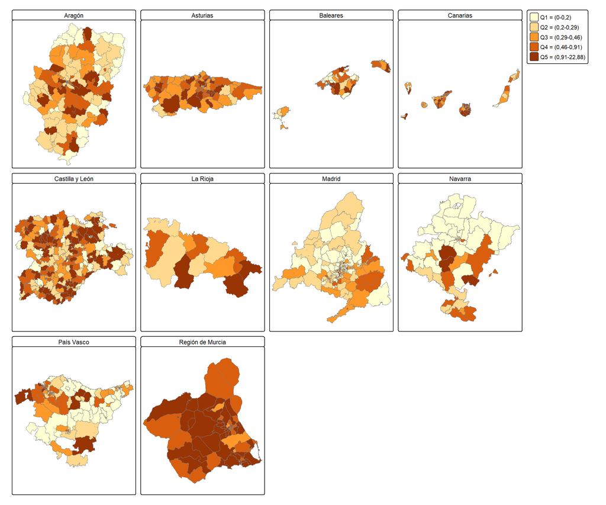

**Derivados de oripavina (N02AE)**

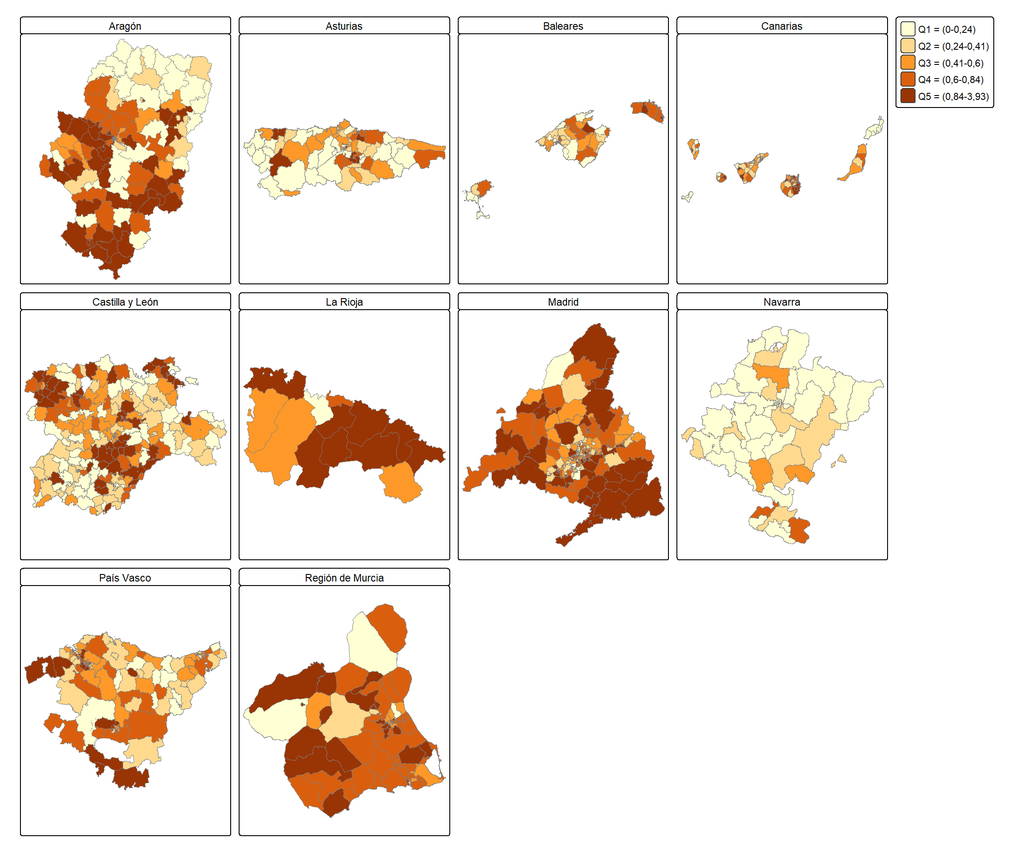

## Evolución de la variación por ZBS de los indicadores de utilización de analgésicos opioides

**Descripción figura**

Se muestra la evolución de la variación por CCAA del porcentaje de envases dispensados en las zonas básicas de salud que componen el sistema nacional de salud de manera que cada punto es una zona básica. La línea sólida roja es la mediana nacional y la zona sobreada gris es el rango intercuartílico, por lo que son comunes a todas las comunidades.

**% Morfina**

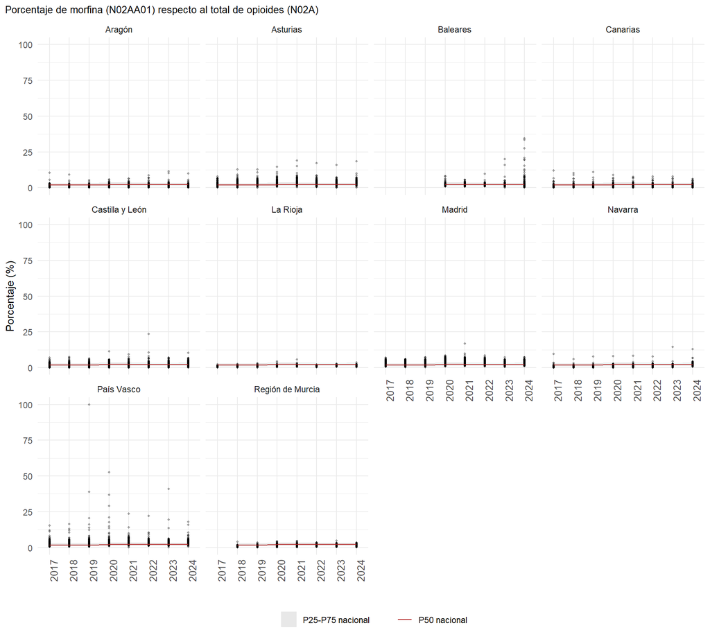

**% Fentanilo**

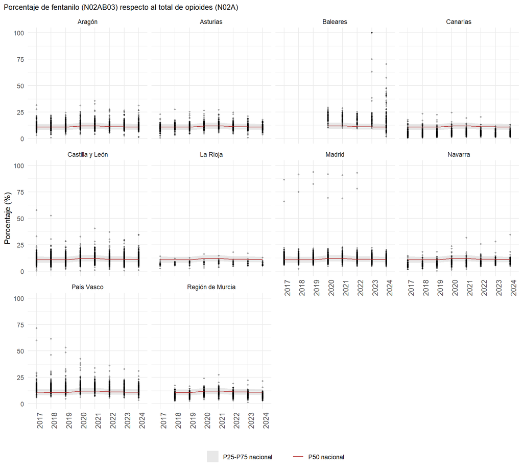

**% Codeína**

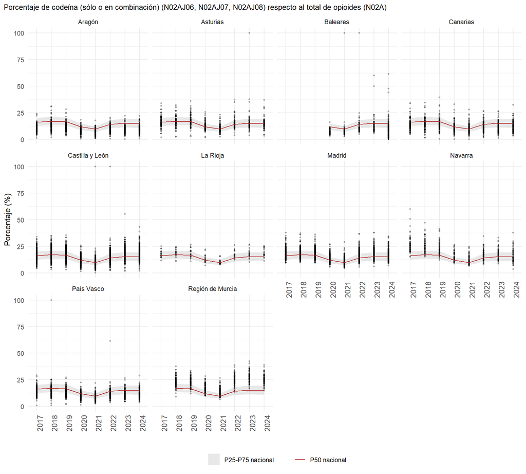

**% Oxicodona**

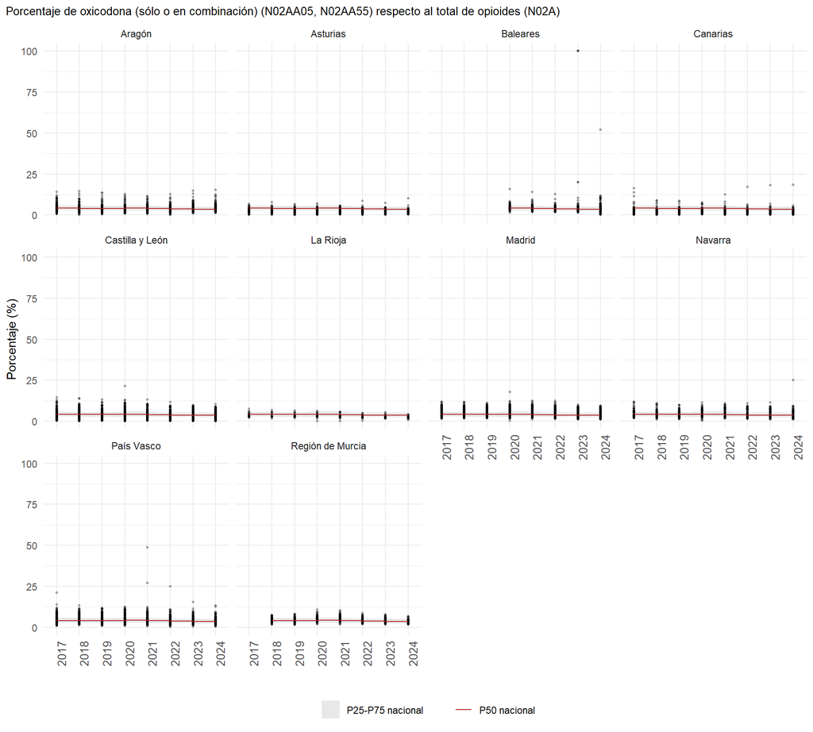